# Aplicando a teoria do valor extremo no cálculo de risco de índices setoriais da Bovespa

06/09/2018

## Agenda

- Situação Problema
- Valor em Risco - VaR
- Teoria do Valor Extremo - EVT
- Modelo GARCH
- Índices Utilizados
- Resultados

Grupo de Pesquisa em Economia Aplicada - GEA

## Situação Problema

- Princípios de Basileia
- Instituições Financeiras devem manter reservas de capital contra riscos de mercado, crédito, liquidez, entre outros
- Estimação excessiva do risco gera excesso de capital em reserva. Custo para a instituição.
- Subestimação deste risco pode levar a IF a uma crise de liquidez e eventualmente a insolvência.
- Risco de mercado medio por Valor em Risco - VaR

Grupo de Pesquisa em Economia Aplicada - GEA

## Objetivo

- Avaliar dois modelos de estimação de VaR
- Índices setoriais Bovespa
  - Financeiro (IFNC)
  - Consumo (ICON)
  - Industrial (INDX)
  - Materiais (IMAT)
  - Governança (IGCX)
  - IBovespa (IBOV)
- Avaliação do modelo mais adequado através de dois testes estatísticos
  - Cobertura incondicional
  - Independência das violações

Grupo de Pesquisa em Economia Aplicada - GEA

## Valor em Risco

### definição

- VaR é uma medida de risco de mercado do portfolio
- Maior valor de perda esperado para um determinado período e dado nível de confiança
- VaR é um quantil \(\alpha\) da distribuição de perdas que delimita a cauda.

Grupo de Pesquisa em Economia Aplicada - GEA

## VaR

### distribuição de perdas

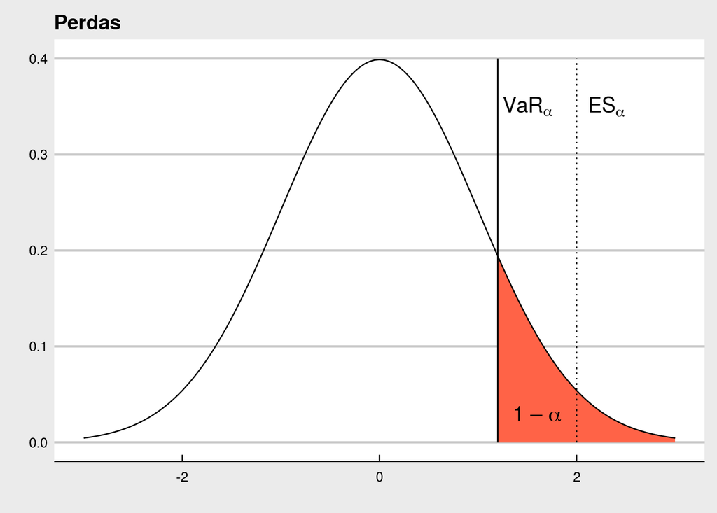

Grupo de Pesquisa em Economia Aplicada - GEA

## Teoria do valor extremo

### fundamentos

- EVT é um ramo da estatística que trata de eventos raros, distantes da mediana
- Aplicações em hidrologia, geologia, seguros e finanças, entre outros
- Distribuições de probabilidade com caudas longas
- É adequada aos fatos estilizados dos retornos financeiros
  - Curtose em excesso
  - Assimetria nos retornos
  - Heterocedasticidade condicional

Grupo de Pesquisa em Economia Aplicada - GEA

## Teoria do valor extremo

### definições

- Existem duas abordagens para a EVT
  - Máximos em bloco - \(M_n\)
  - Peaks-over-threshold - POT
- POT é a mais utilizada na prática
- Desperdiça um menor número de observações

Grupo de Pesquisa em Economia Aplicada - GEA

## Teoria do valor extremo

### definições

**Definição**(Distribuição de valores extremos generalizada - GEV). Uma distribuição GEV é definida por sua função de densidade de probabilidade:

\[ H_\xi(x) = \begin{cases} exp(-(1+\xi x)^{-\frac{1}{\xi}}), & \xi \neq 0,\\ exp(-e^{-x}), & \xi = 0,\\ \end{cases} \]

- Teorema de Fisher-Tippett-Gnedenko demonstra que a distribuição de \(M_n\) quando \(n \rightarrow \infty\) converge para uma GEV e diz-se que \(F \in MDA(H_\xi)\)
- Nossa distribuição de perdas \(F\) pertence ao domínio de atração de máximos de \(H_\xi\)

Grupo de Pesquisa em Economia Aplicada - GEA

## Teoria do valor extremo

### definições

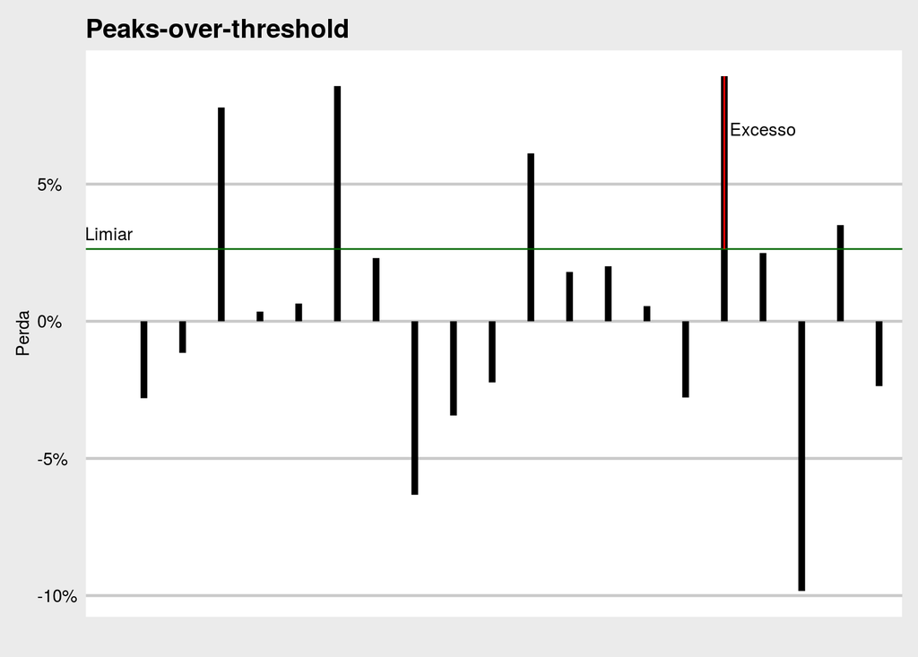

Grupo de Pesquisa em Economia Aplicada - GEA

## Teoria do valor extremo

### definições

**Teorema** (Pickands-Balkema-de Haan): Seja *X* uma variável aleatória com função de distribuição \(F \in MDA(H_\xi)\). A distribuição dos excessos sobre um limiar *u* adequado tem a função de Distribuição Generalizada de Pareto - GPD:

\[ G_{\xi,\psi(u)}(X) = \begin{cases} 1- \left(1+ \frac{\xi x}{\psi(u)} \right)^{-\frac{1}{\xi}}, & \xi \neq 0,\\ 1-exp\left(-\frac{x}{\psi(u)}\right), & \xi = 0,\\ \end{cases} \]

- Se \(F \in MDA(H_\xi)\), então a distribuição dos excessos \(F_u \rightarrow G_{\xi,\psi(u)}\)

Grupo de Pesquisa em Economia Aplicada - GEA

## Teoria do valor extremo

### peaks-over-threshold

- Como se deve escolher o valor **adequado** do limiar?
  - Gráficos de vida residual média (função média dos excessos *versus* *u*)
  - Escolher o menor valor de *u* onde a relação é linear
  - Na prática, número de excessos observados em torno de 100
- *Trade-off* entre limiar alto e número de excessos
  - Limiar muito baixo, teorema PBH não é satisfeito
  - Limiar muito alto, poucos excessos e alta variância nos parâmetros \(\xi\) e \(\psi\)

Grupo de Pesquisa em Economia Aplicada - GEA

## Modelo EVT Condicional

### dois estágios

- Seguiu-se os passos propostos por McNeil and Frey (2000)
- Estimação feita em dois passos
  - Filtragem GARCH
    - Modelo GARCH(1, 1) de Bollerslev (1986) para retirar heterocedasticidade
    - Resíduos padronizados podem ser tratados como *iid*
  - Aplicação da EVT aos resíduos padronizados
- Modelo completo para a medida de risco \(VaR_\alpha\) condicional

\[ \begin{align*} \mu_t=\;&\mu+ \phi_1 \mu_{t-1}+ \varepsilon_t \\ \varepsilon_t=\;&\sigma_t Z_t\\ \sigma_t^2=\;&\omega+ \alpha_1 \varepsilon_{t-1}^2+ \beta_1 \sigma_{t-1}^2 \\ Z_t\sim \;&\mathcal{D}(0,1) \text{ e } \mathcal{D} \in MDA(H_\xi) \end{align*} \]

Grupo de Pesquisa em Economia Aplicada - GEA

## VaR parametrizado

### EVT condicional

\[ VaR_\alpha^t=\mu_{t+1}+\sigma_{t+1}z_\alpha \]

- \(z_\alpha\) é o quantil \(\alpha\) das inovações *Z* obtido pela EVT

\[ z_\alpha=q_\alpha(F_z) = u+\frac{\psi}{\xi}\left[ \left( \frac{1-\alpha}{\bar{F_z}(u)}\right)^{-\xi}-1 \right] \]

### Riskmetrics

\[ \begin{align} \mu_t=\;& \varepsilon_t\\ \varepsilon_t=\;& \sigma_tZ_t\\ \sigma^2_t=\;& (1-\lambda)\varepsilon^2_{t-1}+\lambda \sigma^2_{t-1}\\ VaR_\alpha^t=\;& \sigma_{t+1}\Phi^{-1}(\alpha) \end{align} \]

Grupo de Pesquisa em Economia Aplicada - GEA

## Seis índices de ações

### segmentos da Bovespa

- Seis principais índices setoriais de ações da Bovespa, por valor de mercado
  - Financeiro (IFNC)
  - Consumo (ICON)
  - Industrial (INDX)
  - Materiais (IMAT)
  - Governança (IGCX)
  - e o próprio índice Bovespa (IBOV)
- Retornos diários
  - Período dentro da amostra: 01/01/2009 a 31/12/2013
  - Período fora da amostra: 01/01/2014 a 08/05/2018

Grupo de Pesquisa em Economia Aplicada - GEA

## Estatísticas descritivas

### retornos não são normais

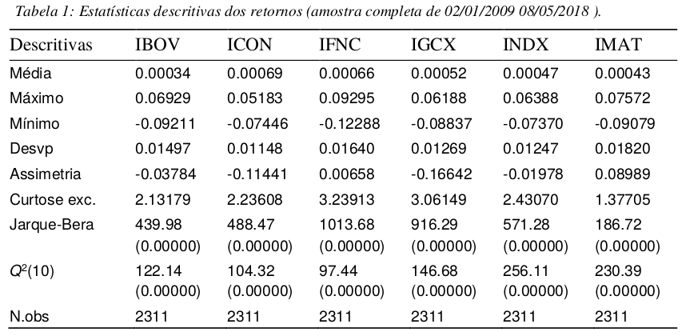

Grupo de Pesquisa em Economia Aplicada - GEA

## QQ plots

### retornos não são normais

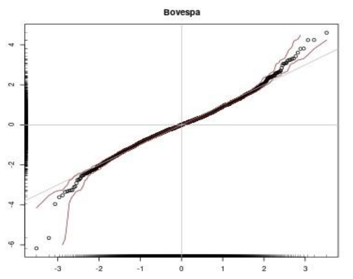

Grupo de Pesquisa em Economia Aplicada - GEA

## Descritivas pós filtragem

### sem autocorrelação na variância

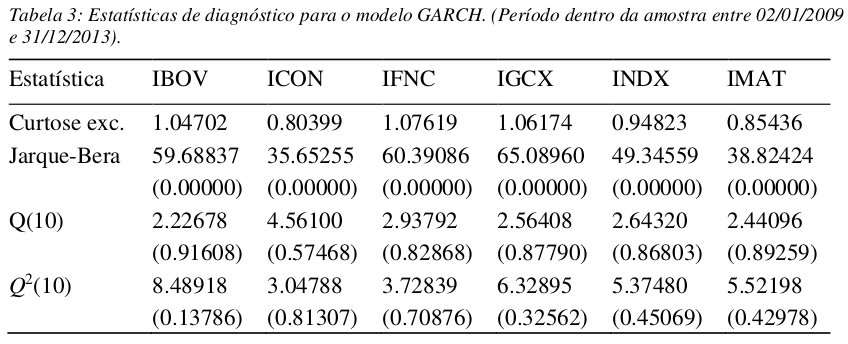

Grupo de Pesquisa em Economia Aplicada - GEA

## Método POT

### aplicação aos resíduos padronizados

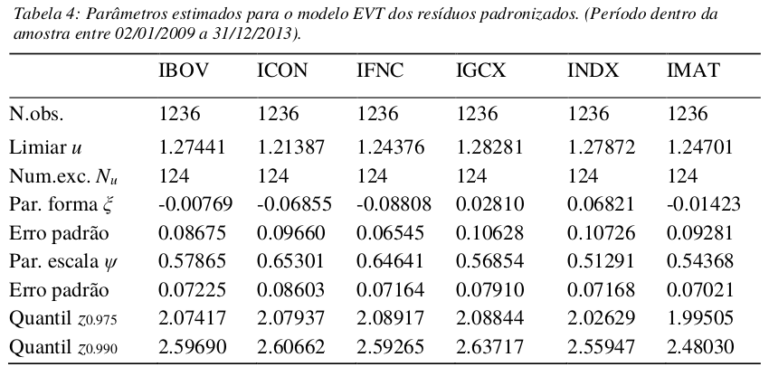

Grupo de Pesquisa em Economia Aplicada - GEA

## Ajuste EVT

### melhor aderência

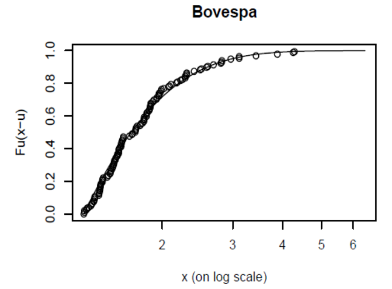

Grupo de Pesquisa em Economia Aplicada - GEA

## Gráficos dos modelos

### EVT *vs* Riskmetrics

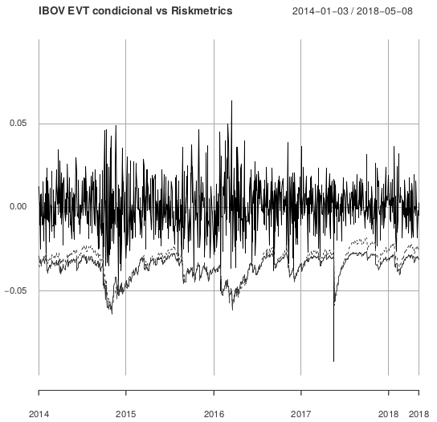

Grupo de Pesquisa em Economia Aplicada - GEA

## Violações

### quando a perda é maior que o VaR

- Violações ocorrem quando \(\mu_{t+1} > VaR_\alpha^t\)
- Modelo bem especificado
  - percentual de violações igual a \(1-\alpha\)
  - violações são independentes entre si
- \(1 - \alpha\) é a cobertura incondicional

Grupo de Pesquisa em Economia Aplicada - GEA

## Sumário de violações

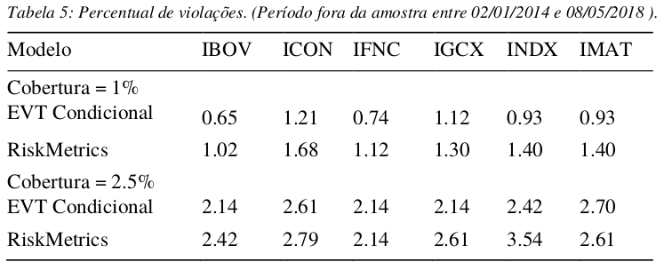

Grupo de Pesquisa em Economia Aplicada - GEA

## Testes Estatísticos

### cobertura incondicional e independência

### Teste de Kupiec de cobertura incondicional

- Inferir se a frequência de violações ao VaR é consistente com o nível de cobertura
- H0: modelo corretamente especificado
- Sob H0, a estatística \(LR_{uc}\) segue uma distribuição \(\chi^2_1\)

### Teste de Christoffersen & Pelletier de independência

- Inferir se as violações não formam agrupamentos previsíveis
- H0: modelo corretamente especificado
- Única distribuição **sem** memória, exponencial
  - Weibull é caso particular
  - Teste sobre o parâmetro que se igual a 1 se torna exponencial

Grupo de Pesquisa em Economia Aplicada - GEA

## Testes Estatísticos

### cobertura incondicional e independência

### Teste de Kupiec de cobertura incondicional

\[LR_{uc}=-2\ln\left(\frac{(1-p)^{N-X}p^X}{(1-\frac{X}{N})^{N-X}(\frac{X}{N})^X}\right)\]

onde:

- \(p\) nível de cobertura
- \(N\) número de observações do período fora da amostra, e
- \(X\) número de violações

\(H0: LR_{uc}\rightarrow \chi^2_{df=1}\)

Grupo de Pesquisa em Economia Aplicada - GEA

## Testes Estatísticos

### cobertura incondicional e independência

### Teste de Christoffersen & Pelletier de independência

\[ f_W(D; a, b) = \begin{cases} a^b b D^{b-1}e^{-(aD)^b}, &D \geq 0\\ 0,&D<0. \end{cases} \]

onde:

- \(D\) duração entre violações

\(H0: b = 1\)

Grupo de Pesquisa em Economia Aplicada - GEA

## Sumário de rejeições de modelo bem especificado

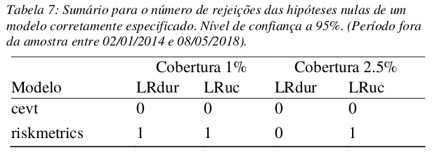

- Número de rejeições possíveis igual a 6
- Modelo riskmetrics apresentou rejeição de modelo bem especificado para algum índice

Grupo de Pesquisa em Economia Aplicada - GEA

## Muito Obrigado!

Grupo de Pesquisa em Economia Aplicada - GEA

## Perguntas e Respostas

### tabela completa de testes

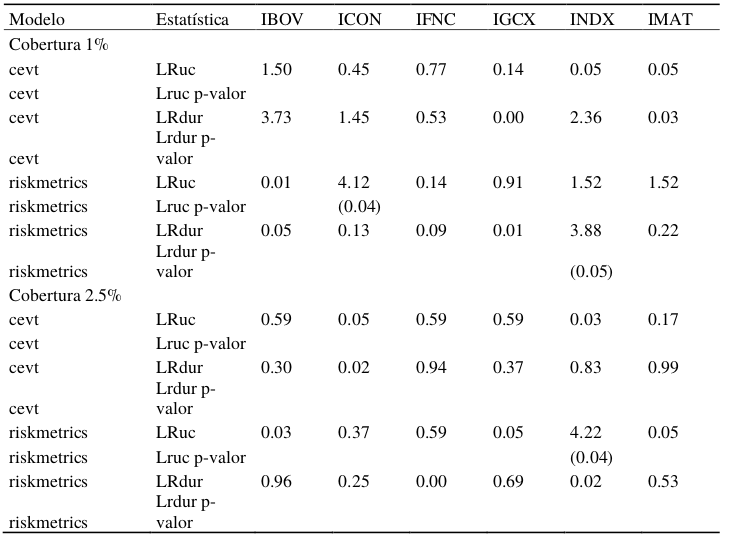

Grupo de Pesquisa em Economia Aplicada - GEA

## Referências

Bollerslev, Tim. 1986. “Generalized autoregressive conditional heteroskedasticity.” *Journal of Econometrics* 31 (3): 307–27. doi:10.1016/0304-4076(86)90063-1.

McNeil, Alexander J, and Rüdiger Frey. 2000. “Estimation of tail-related risk measures for heteroscedastic financial time series: an extreme value approach.” *Journal of Empirical Finance* 7 (3-4): 271–300. doi:10.1016/s0927-5398(00)00012-8.

Grupo de Pesquisa em Economia Aplicada - GEA